# hw1_Mohapatra

Tanisha Mohapatra

2/18/2018

```r
knitr::opts_chunk$set(echo = TRUE)
library(tibble)
library(dplyr)
```

```r
library(ggplot2)
download.file("https://raw.githubusercontent.com/GarciaRios/govt_6029/master/data/democracy.csv", destfile = "Lab1")
lab1data <- read.csv("Lab1", stringsAsFactors = FALSE, na.strings = ".")
```

### Initial Data Exploration

**Summary Statistics**

The summary statistics are generated by the code below.

```r
summary(lab1data) #Summary Statistics for all variables
```

```
##     COUNTRY         CTYNAME             REGION               YEAR
##  Min.   :  1.00   Length:4126        Length:4126        Min.   :1951
##  1st Qu.: 39.00   Class :character   Class :character   1st Qu.:1965
##  Median : 71.00   Mode  :character   Mode  :character   Median :1974
##  Mean   : 70.18                                         Mean   :1973
##  3rd Qu.:103.00                                         3rd Qu.:1983
##  Max.   :135.00                                         Max.   :1990
##
##     BRITCOL            CATH           CIVLIB           EDT
##  Min.   :0.0000   Min.   : 0.00   Min.   :1.000   Min.   : 0.030
##  1st Qu.:0.0000   1st Qu.: 0.00   1st Qu.:2.000   1st Qu.: 2.214
##  Median :0.0000   Median :22.25   Median :5.000   Median : 4.540
##  Mean   :0.2433   Mean   :37.20   Mean   :4.076   Mean   : 4.853
##  3rd Qu.:0.0000   3rd Qu.:84.00   3rd Qu.:6.000   3rd Qu.: 7.085
##  Max.   :1.0000   Max.   :99.00   Max.   :7.000   Max.   :12.810
##                                   NA's   :1727    NA's   :1226
##      ELF60             GDPW           MOSLEM           NEWC
##  Min.   :0.0000   Min.   :  480   Min.   : 0.00   Min.   :0.0000
##  1st Qu.:0.1000   1st Qu.: 2458   1st Qu.: 0.00   1st Qu.:0.0000
##  Median :0.3700   Median : 6012   Median : 0.50   Median :0.0000
##  Mean   :0.3995   Mean   : 8877   Mean   :19.74   Mean   :0.4561
##  3rd Qu.:0.6900   3rd Qu.:12608   3rd Qu.:16.20   3rd Qu.:1.0000
##  Max.   :0.9300   Max.   :37903   Max.   :99.90   Max.   :1.0000
##  NA's   :542
##       OIL             POLLIB          REG              STRA
##  Min.   :0.0000   Min.   :1.00   Min.   :0.0000   Min.   :0.0000
##  1st Qu.:0.0000   1st Qu.:2.00   1st Qu.:0.0000   1st Qu.:0.0000
##  Median :0.0000   Median :3.00   Median :0.0000   Median :0.0000
##  Mean   :0.1001   Mean   :3.86   Mean   :0.3987   Mean   :0.3752
##  3rd Qu.:0.0000   3rd Qu.:6.00   3rd Qu.:1.0000   3rd Qu.:1.0000
##  Max.   :1.0000   Max.   :7.00   Max.   :1.0000   Max.   :5.0000
##                   NA's   :1727
```

**Histograms**

The code below generates the following histograms: 1. Political Liberties (with each degree as its own bin) 2. GDP per capita 3. GDP per capita (Log Values)

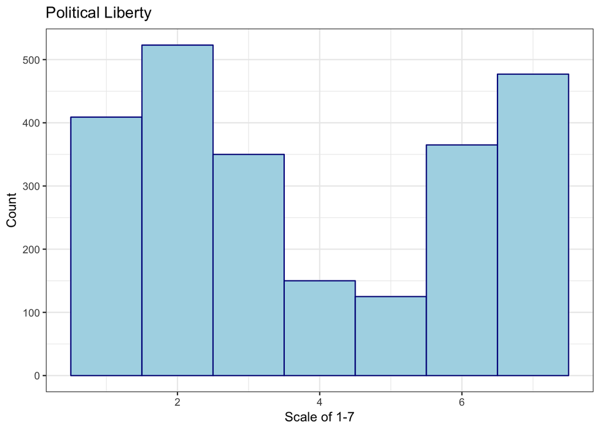

```r
ggplot(lab1data, aes(x=POLLIB)) +
  geom_histogram(binwidth = 1, color = "darkblue", fill = "lightblue") +
  xlab("Scale of 1-7") + ylab("Count") + ggtitle("Political Liberty") + theme_bw() #Political Liberty histogram
```

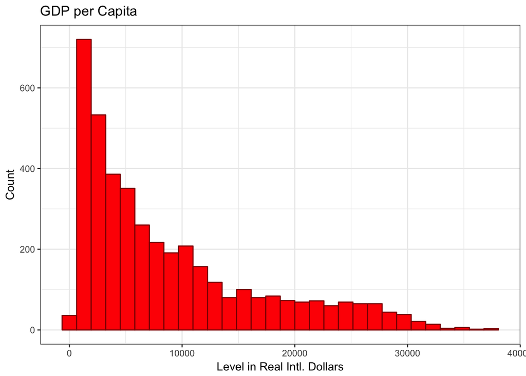

```r
ggplot(lab1data, aes(x=GDPW)) +
  geom_histogram(color = "darkred", fill = "red") +
  xlab("Level in Real Intl. Dollars") + ylab("Count") + ggtitle("GDP per Capita") + theme_bw() #GDPperCap histogram
```

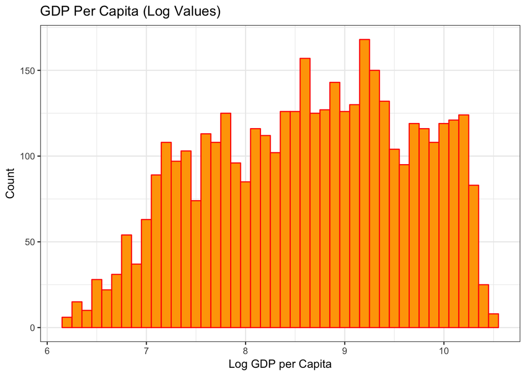

```r
ggplot(lab1data, aes(x=log(GDPW))) +
  geom_histogram(binwidth = 0.1, color = "red", fill = "orange") +
  xlab("Log GDP per Capita") + ylab("Count") + ggtitle("GDP Per Capita (Log Values)") + theme_bw() #LogGDPperCap histogram
```

Note the difference between the histograms for GDP per capita and that for GDP per Capita (Log Values). Whereas the histogram for GDP exhibits a heavy right skew, that is not the case with log GDP. With heavily skewed data (as was the case for GDP per capita), using a log transformation reduces the skew so that useful observations about the data can be made.

### Explore Relationships

**GDP and Poltical Liberty**

The code below creates a scatter plot to capture the relationship between GDP per capita and Political Liberty. As can be observed from the first graph, there is a lot of overlap between the plot points. Therefore, the second graph (with red points) randomly “jitters” the points up and down to mitigate the overplotting problem.

Next, we observe changes to the graph pattern when we consider log values of GDP. Recall the difference observed in the previous section between the hisograms for just GDP (heavy right skew) and log GDP. Without jitters, there is a lot of overlap in the plot points. After using jitters, we can observe the difference between this graph and the second graph with red points that did not use log values for GDP per capita. Whereas the plot points were heavily concentrated in the left area of the graph in the non-log relationship, they are more evenly distributed in the log relationship, allowing us to make observations more easily.

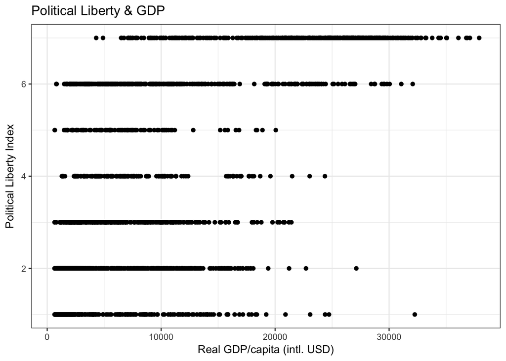

```r
ggplot(lab1data, aes(x = GDPW, y = POLLIB)) +
  geom_point() +
  theme_bw() +
  labs(title = "Political Liberty & GDP", y = "Political Liberty Index", x = "Real GDP/capita (intl. USD)") #GDP per capita vs POLLIB
```

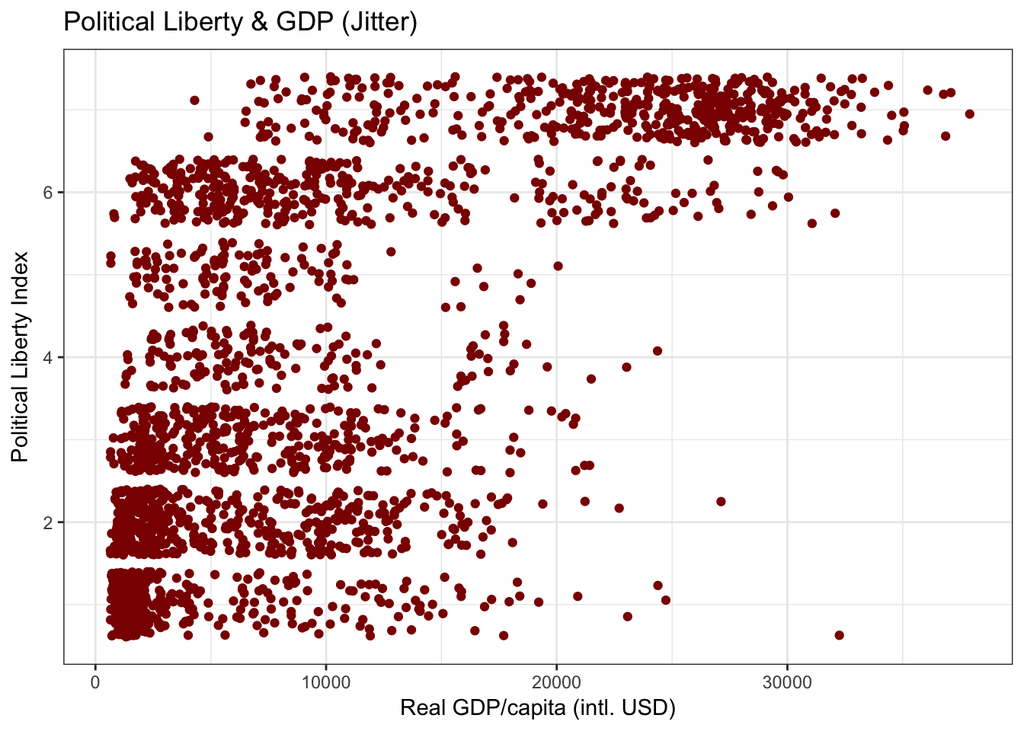

```r
ggplot(lab1data, aes(x = GDPW, y = POLLIB)) +
  geom_jitter(color = "darkred", fill = "red") +
  theme_bw() +
  labs(title = "Political Liberty & GDP (Jitter)", y = "Political Liberty Index", x = "Real GDP/capita (intl. USD)") #GDP per capita vs POLLIB -- jittered
```

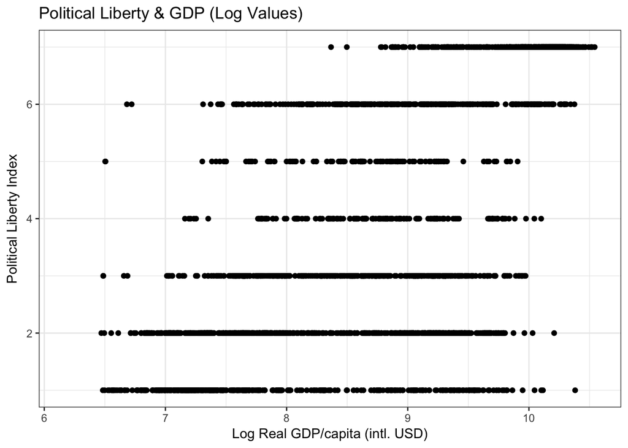

```r
ggplot(lab1data, aes(x = log(GDPW), y = POLLIB)) +
  geom_point() +
  theme_bw() +
  labs(title = "Political Liberty & GDP (Log Values)", y = "Political Liberty Index", x = "Log Real GDP/capita (intl. USD)") #Log GDPW and POLLIB
```

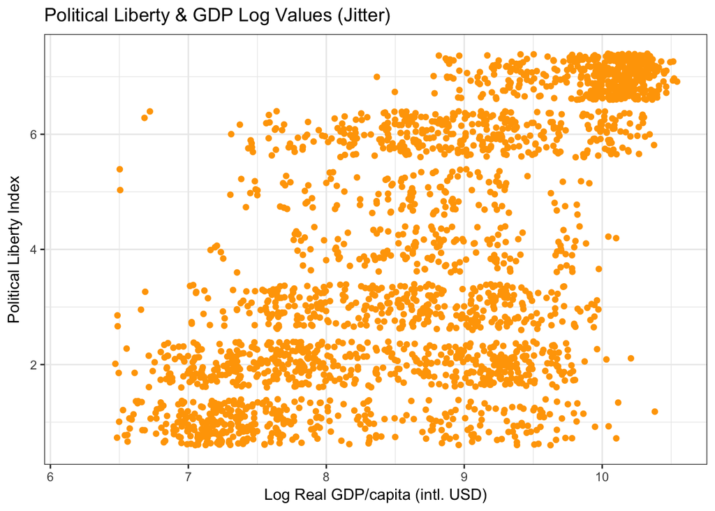

```r
ggplot(lab1data, aes(x = log(GDPW), y = POLLIB)) +
  geom_jitter(color = "orange") +
  theme_bw() +
  labs(title = "Political Liberty & GDP Log Values (Jitter)", y = "Political Liberty Index", x = "Log Real GDP/capita (intl. USD)") #Log GDPW and POLLIB -- jittered
```

**GDP and Oil Production** In this section, we will use box plots to observe the relationship between GDP per capita and whether oil comprises more than 50% of the country’s exports. First, I am converting the variable OIL into a factor variable so that the data is recognized as discrete for the purpose of the boxplot. The code below generates a side by side boxplot showing the data patterns for per capita GDP levels in countries where oil less than 50% of exports, and in countries where oil is more than 50% of exports.

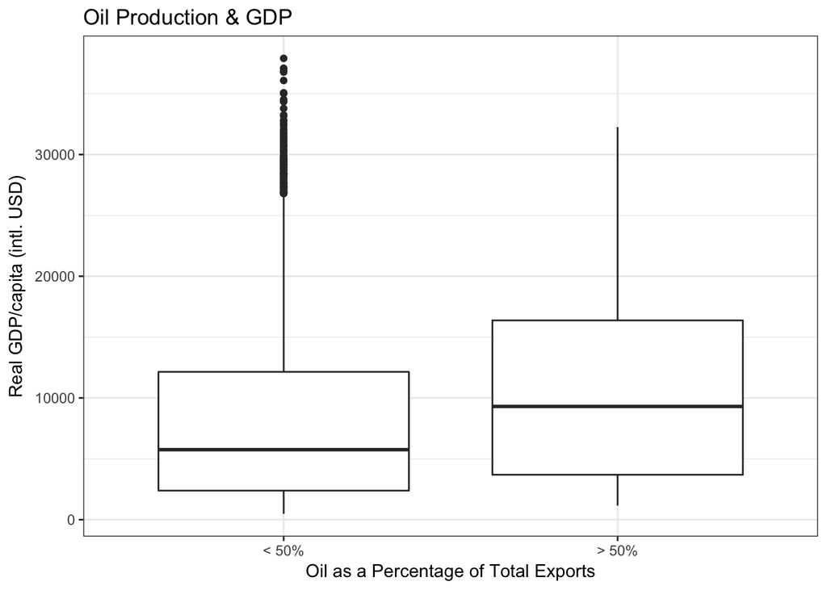

```r
lab1data$OILfactor <- as.factor(lab1data$OIL) #discrete
ggplot(lab1data, aes(x = OILfactor, y = GDPW)) +
  geom_boxplot() +
  theme_bw() +
  labs(title = "Oil Production & GDP", x = "Oil as a Percentage of Total Exports", y = "Real GDP/capita (intl. USD)")+
  scale_x_discrete(labels = c('< 50%','> 50%'))
```

From this boxplot, we can observe that the median per capita GDP level is higher for countries whose exports are comprised > 50% by oil. For these countries which have more than 50% of expors as oil, the 25th and 75th percentile is also higher, as is the interquartile range, however, we should note that for countries that have less than 50% of exports made up of oil, the total range for all values is bigger, but the upper bound is characterized with numerous outliers. Additionally, these countries (those in the < 50% bracket) have a per capita GDP distribution that is skewed right. In sum, we can conclude that big oil exporters will probably have a higher level of per capita GDP just by looking at this distribution.

### Transform Data and Analyze

**Per Capita GDP & Religious Demographics**

```r
mean(lab1data$GDPW)
```

```
## [1] 8876.959
```

```r
cath40 <- filter(lab1data, CATH >= 40)
mean(cath40$GDPW)
```

```
## [1] 10295.13
```

**Ethnolinguistic Fractionalization**

The code below returns the average per capita GDP levels for varying levels of ethnolinguistic fractionalization.

```r
summary(lab1data$ELF60) #Note there are 542 NAs.
```

```
##    Min. 1st Qu.  Median    Mean 3rd Qu.    Max.    NA's
##  0.0000  0.1000  0.3700  0.3995  0.6900  0.9300     542
```

```r
mean(filter(lab1data, ELF60 > 0.6)$GDPW) #avg gdp for elf60 > 60%
```

```
## [1] 3590.939
```

```r
mean(filter(lab1data, ELF60 < 0.6)$GDPW) #avg gdp for elf60 < 60%
```

```
## [1] 11803.78
```

```r
mean(filter(lab1data, ELF60 == 0)$GDPW) #avg gdp for elf60 = 0%
```

```
## [1] 6307.946
```

```r
mean(filter(lab1data, is.na(ELF60))$GDPW) #avg gdp for elf60 as missing value (NA)
```

```
## [1] 7767.245
```

- Mean GDP for countries with > 60% ethnolinguistic fractionalization = $3590.95
- Mean GDP for countries with < 60% ethnolinguistic fractionalization = $11803.78
- Mean GDP for countries with zero ethnolinguistic fractionalization = $6307.946
- Mean GDP for countries that are missing any reported ethnolinguistic fractionalization (ELF60 = NA) = $7767.245

**Education Levels in 1985**

What was the median of the average years of education in 1985 for all countries? 5.625 years. Note that the code gives us the median with the 22 NAs, so this may not be the true median since the EDT vector in 1985 has missing values.

Which country was (or countries were) closest to the median years of education in 1985 among all countries? Venezuela had the median of average years of education of 5.625 years. Closest after Venezuela were El Salvador (5.725 years) and Lesotho (5.52 years).

What was the median of the average years of education in 1985 for democracies? 7.805 years. Note that this gives us the median with the 6 NAs, so this may not be the true median since the vector has missing values.

Which democracy was (or democracies were) closest to the median years of education in 1985 among all democracies? Mauritius had the median of average years of education of 7.805 years. Closest after Mauritius were Greece (7.485 years) and France (7.91 years).

```r
summary(filter(lab1data, YEAR == 1985)$EDT) #Summary statisitics for 1985 education levels. Note that this gives us the median with the 22 NAs, so this may not be the true median since the vector has missing values.
```

```
##    Min. 1st Qu.  Median    Mean 3rd Qu.    Max.    NA's
##   0.625   3.520   5.625   5.960   7.810  12.810      22
```

```r
lab1data %>%
  filter(YEAR == 1985, EDT > 5.5 & EDT< 6) %>%
  select(CTYNAME, EDT) %>%
  arrange() #arranging countries within a small range close to the median we previously found.
```

```
##       CTYNAME   EDT
## 1     Lesotho 5.520
## 2 El Salvador 5.725
## 3   Venezuela 5.625
## 4    Thailand 5.995
```

```r
summary(filter(lab1data, YEAR == 1985, REG == 1)$EDT) #Summary statistics for 1985 education levels in democracies only. Note that this gives us the median with the 6 NAs, so this may not be the true median since the vector has missing values.
```

```
##    Min. 1st Qu.  Median    Mean 3rd Qu.    Max.    NA's
##   1.740   6.150   7.805   8.074  10.250  12.810       6
```

```r
lab1data %>%
  filter(YEAR == 1985, REG == 1 , EDT > 7.4 & EDT< 8) %>%
  select(CTYNAME, EDT) %>%
  arrange() #arranging countries within a small range close to the median we previously found.
```

```
##     CTYNAME   EDT
## 1 Mauritius 7.805
## 2    France 7.910
## 3    Greece 7.485
```

**Ethnolinguistic Fractionalization in Old and New Countries**

The code below generates the summary statisitics for “old” and “new” countries. Old and New are classifications based on whether the country was created before 1945 (old) or whether the country was created after 1945 (new). This is captured by the variable NEWC which takes dummy values of 0 for old and 1 for new countries.

```r
#Old Countries
lab1data %>%
  filter(NEWC == 0) %>%
  select(ELF60) %>%
  summary()
```

```
##      ELF60
##  Min.   :0.0000
##  1st Qu.:0.0600
##  Median :0.1600
##  Mean   :0.2688
##  3rd Qu.:0.4400
##  Max.   :0.8800
##  NA's   :291
```

```r
#New Countries
lab1data %>%
  filter(NEWC == 1) %>%
  select(ELF60) %>%
  summary()
```

```
##      ELF60
##  Min.   :0.040
##  1st Qu.:0.420
##  Median :0.650
##  Mean   :0.556
##  3rd Qu.:0.750
##  Max.   :0.930
##  NA's   :251
```

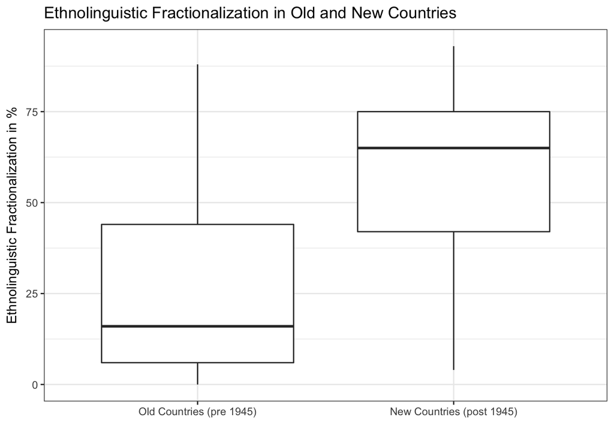

```r
#side by side box plot
lab1data$NEWCfactor <- as.factor(lab1data$NEWC) #discrete
ggplot(lab1data, aes(x = NEWCfactor, y = ELF60*100)) +
  geom_boxplot() +
  theme_bw() +
  labs(title = "Ethnolinguistic Fractionalization in Old and New Countries", x = "", y = "Ethnolinguistic Fractionalization in %")+
  scale_x_discrete(labels = c('Old Countries (pre 1945)','New Countries (post 1945)'))
```

For Old Countries, the 25th percentile is 0.06, translating to 6% fractionalization as the 25th percentile in Old Countries if the index caputures percentages reported as decimals. The 75th percentile is 0.44 translating to 44% fractionalization as the 75th percentile (assuming the index captures percentages reported as decimals). Note that there are 291 missing values here.

This big difference in the distribution of levels of ethnolinguistic fractionalization in old versus new countries is clear from the side by side box plot.